# Job Insecurity: An Integrative Review and Agenda for Future Research

Converted from PDF `Shoss-JobInsecurityReview-2017-JOM.pdf` · 29 pages · anchors: page `#pN`, block `#pN-bK`

Page 1

https://doi.org/10.1177/0149206317691574

Journal of Management Vol. 43 No. 6, July 2017 1911–1939

DOI: 10.1177/0149206317691574

© The Author(s) 2017 Reprints and permissions: sagepub.com/journalsPermissions.nav

1911

## Job Insecurity: An Integrative Review

## and Agenda for Future Research

#### Mindy K. Shoss

*University of Central Florida*

*Job insecurity reflects a threat to the continuity and stability of employment as it is currently experienced. Job insecurity has been the focus of increasing scholarly and popular attention in light of technological, economic, and political changes over the past few decades that have left many insecure about the future of their jobs. Yet, conceptual ambiguities exist; the literature remains fragmented; and there lacks an overarching framework through which to organize and reconcile findings. The goal of this article is to offer an integrative review and conceptual framework that addresses these challenges and provides the groundwork for future research. To that end, it proposes a definition of job insecurity that differentiates it from potential antecedents, moderators, and outcomes. The article addresses antecedents and introduces a typology of mechanisms and threat foci that links antecedents to job insecurity and suggests yet unexplored predictors. Furthermore, the framework developed here considers four overarching mechanisms—stress, social exchange, job preservation motivation, and proactive coping—through which job insecurity leads to various outcomes, and it highlights potential competing tensions inherent in individuals’ responses. Finally, the framework introduces threat features, economic vulnerabilities, and psychological vulnerabilities as three overarching categories of variables that moderate reactions to job insecurity, and it identifies factors that contribute to each. In doing so, it suggests important levers through which to influence reactions to job insecurity; it helps explain variability in past research; and it provides a foundation for future work.*

*Keywords:* *job insecurity; occupational health and safety; psychological contract; organiza-*

*tional change; labor market policies*

*Acknowledgments: This article benefited greatly from the insightful comments and suggestions made by the two anonymous reviewers and the action editor, Brian Hoffman, throughout the review process. I also thank Lixin Jiang, Dustin Jundt, Kristi Lavigne, Tahira Probst, Cort Rudolph, and members of the Work Stress in Context Lab at the University of Central Florida for their helpful feedback on previous versions. In addition to serving on the faculty at the University of Central Florida, Mindy Shoss is a professorial fellow in the Centre for Sustainable Human Resource Management and Wellbeing at Australian Catholic University.*

*Corresponding author: Mindy K. Shoss, Department of Psychology, University of Central Florida, Psychology Building, 4111 Pictor Lane, Orlando, FL 32816, USA.*

*E-mail: mindy.shoss@ucf.edu*

Page 2

1912 Journal of Management / July 2017

The history of work is that of transformation. Over the past few decades, transformative technological, economic, and political changes surrounding work have left many insecure about the future of their jobs (Benach et al., 2014). In particular, technological advances, despite many benefits, have altered job tasks and demand for certain types of work (Kalleberg, 2011). Global competition has placed pressure on organizations to cut costs and adapt business practices (Ahean, 2012). Increasing ties to financial markets have exposed employers and employees to their ebb and flow (G. F. Davis, 2009). Against a backdrop of declining union power, it appears that stability and predictability in employment have been increasingly replaced by job insecurity (JI) as employers downsize, outsource labor, and demand that employees do more with less.

Not surprising, JI has become a topic of increasing scholarly and popular concern. JI has been characterized as a threat to population health (Burgard, Brand, & House, 2009), a potential mechanism behind health inequalities (Benach et al., 2014), and a tipping-point phenomenon both driving and resulting from organizational decline (Greenhalgh & Rosenblatt, 2010). Indeed, empirical evidence links JI to poor mental, physical, and work-related wellbeing; poor job attitudes; and decrements in performance, creativity, and adaptability (e.g., Cheng & Chan, 2008; De Witte, Pienaar, & De Cuyper, 2016; Ferrie et al., 2001; Niessen & Jimmieson, 2016; Probst, Stewart, Gruys, & Tierney, 2007). Yet, at the same time, some argue that job security creates complacency (Brockner, Grover, Reed, & Dewitt, 1992), and organizations and policy makers struggle with how to manage the trade-offs between organizational flexibility and employee job security (European Commission, 2007).

This article aims to move the JI literature forward in several important ways. First, it addresses issues of construct conceptualization and measurement and, in doing so, aims to provide future research with a clear conceptualization of JI and recommendations for measurement. Second, it consolidates and extends knowledge regarding antecedents of JI by offering a typology of mechanisms and threat foci that links antecedents to JI and suggests yet unexplored predictors. Third, the conceptual framework developed here addresses theoretical mechanisms underlying responses to JI and introduces several novel outcomes, including yet unexplored job preservation and proactive coping strategies. Finally, the framework introduces three overarching sets of moderating variables that exacerbate and attenuate employees’ reactions to JI, and identifies factors that contribute to each. In doing so, it consolidates existing knowledge, explains variability in past work, and suggests levers through which reactions to JI can be shaped. The hope is that this framework provides a generative agenda for future research, as well as insights for management practice and for ongoing discussions regarding the consequences of an increasingly insecure world of work.

#### **Conceptual Framework of JI**

This review considers JI’s antecedents, outcomes, and moderators within an overarching conceptual framework, displayed in Figure 1. The framework summarizes existing evidence regarding antecedent conditions and suggests new directions for identifying antecedents based on an underlying conceptual logic regarding how and why JI emerges. The framework coalesces and extends explanations for JI’s effects by proposing four mechanisms through which JI affects outcomes—stress, social exchange, job preservation motivation, and proactive coping. Stress and social exchange mechanisms capture the meaning of threats; job

Page 3

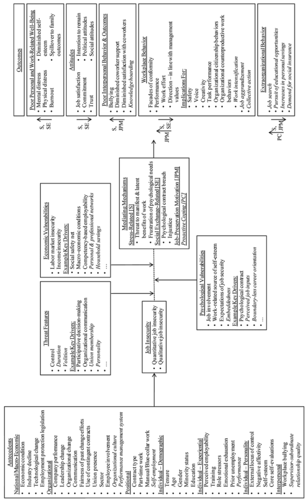

NOTE: figure/graphic rendered as an image from the PDF; its content is not machine-readable text. Caption (if any) follows as the next block.

1913

**Figure 1**

#### **Conceptual Model of Antecedents and Outcomes of Job Insecurity**

*Note:* Variables in italics and ellipses reflect unanswered questions for future work. The arrows on the left of the outcomes illustrate general patterns of corresponding

and competing predictions made by the different mechanisms. Feedback loops are omitted for clarity.

Page 4

1914 Journal of Management / July 2017

preservation motivation and proactive coping respectively capture the ways by which individuals try to keep threats from coming to fruition or prepare themselves in case of eventual loss. Notably, these mechanisms offer corresponding and competing predictions and suggest yet unexplored outcomes of JI. Finally, in light of evidence that not all individuals are equally affected by JI, the framework proposes three overarching categories of variables that moderate reactions to JI by accentuating or attenuating these mechanisms. It also identifies key drivers, or sources, of these moderators. These moderating variables involve features around which threats may vary (i.e., elements of the stimulus), as well as ways in which individuals can be vulnerable to the negative effects of JI—economically (in terms of ease of replacing employment or income if lost) and psychologically (in terms of important identities, roles, and expectations tied to one’s job or its security). Whereas economic vulnerabilities are tied to context (e.g., in terms of the labor market demand, social safety net), psychological vulnerabilities concern elements of the person, in particular the self.

The current framework differs from past treatments in several notable ways. First, the framework does not presume organizational events as the sole initiating causes of JI (Greenhalgh & Rosenblatt, 1984), nor does it restrict the study of JI to only those threats where the job itself (as opposed to the jobholder) is at risk (Jacobson & Hartley, 1991). Second, while existing treatments have been bounded within disparate theoretical perspectives—for example, Ashford, Lee, and Bobko (1989) operate within a psychological contract perspective, whereas Sverke, Hellgren, and Näswall (2002) take a stress perspective—the current framework transcends these perspectives to present a more comprehensive view of the ways in which individuals view and respond to JI and the potential competing tensions in their responses. Third, the framework does not specify outcomes as inherently short- or long-term, in contrast to Sverke et al. (2002), but calls for systematic attention to change over time. Finally, while the literature has largely taken a piecemeal approach toward moderators of JI-outcome relationships, the current framework provides a systematic conceptual basis to organize moderators and understand their effects. Note that while personality is referenced in a general sense in this review, a complete discussion is beyond the scope of this article. Directions for future research are displayed in italics in the figure and discussed throughout.

#### **Defining JI**

The term *job insecurity* is used in a variety of ways (see Table 1 for illustrative definitions). This poses a challenge, as the building of a coherent and practically useful body of knowledge surrounding JI requires a clear conceptualization of the construct. The current paper defines JI as *a perceived threat to the continuity and stability of employment as it is currently experienced.* With this regard, *quantitative JI* denotes perceived threats to the job as a whole (De Witte, 1999; Sverke & Hellgren, 2002), whereas the term *qualitative JI* denotes perceived threats to features of the job, in particular “threats of impaired quality in the employment relationship” (Hellgren, Sverke, & Isaksson, 1999: 182). This definition maintains and coalesces key elements from existing definitions, such as the notion of threat, the emphasis on perception, and the idea that JI can occur when one’s job and job conditions are at risk. However, it omits elements such as expectations for security and involuntary nature of threats in order to distinguish JI from potential antecedents, moderators, and

Page 5

Shoss / Job Insecurity 1915

outcomes and in line with criticisms levied by several authors (e.g., Probst, 2003; Vander Elst, De Cuyper, & De Witte, 2011). JI exists on a continuum from insecure to secure, where employees experience job security when they perceive that the continuity and stability of their jobs are unthreatened. This review focuses on JI as a global construct, instead of more narrowly focusing on its quantitative or qualitative components.

*Defining Characteristics of JI*

This definition points to several core elements of JI. While some of these elements have been variously articulated in other treatments (e.g., De Witte, 1999; T. Van Vuuren, Klandermans, Jacobson, & Hartley, 1991), it is worth highlighting them to be clear about what JI is and what JI is not. First, JI is a subjective experience (De Witte, 1999). This focus

**Table 1 Sample Definitions of Job Insecurity**

[output not shown]

NOTE: table converted from PDF layout to HTML text; cell boundaries are reconstructed. See PDF if exact alignment matters.

Page 6

1916 Journal of Management / July 2017

on perceptions, though consistent with most conceptualizations, contrasts with the designation of jobs as objectively insecure—for example, based on contract type (e.g., temporary workers) or objective organizational circumstance (e.g., layoffs). Given the subjective nature of JI, two persons in the same objective situation may experience very different levels of JI (T. Van Vuuren et al., 1991).

Second, the notion of threat highlights JI as a future-focused phenomenon. JI reflects a forecast about an event, specifically a loss event, which might happen at some point in the future. Thus, not all anticipated or potential job-related events create JI—rather, only those that involve the “potential for harm or loss” (Folkman & Lazarus, 1985: 152; Boswell, Olson-Buchanan, & Harris, 2014). Because threats have not yet materialized, JI involves uncertainty (De Witte, 1999; Probst, 2003; Sverke et al., 2002). Hence, the study of JI is the study of how people perceive and respond to “visualized [job or job feature] loss” (Greenhalgh & Rosenblatt, 1984: 441) as opposed to actual job or job feature loss. Finally, what is under threat in the case of JI is the stability and continuity of one’s current employment—specifically, one’s current job in one’s current organization (De Witte, 1999; Probst, 2003). This differentiates JI from related constructs, such as employability, which captures an individual’s perceived ability to obtain a new job, for example, due to “know-how, skills, knowledge of the labour market, and adaptability” (De Cuyper, Bernhard-Oettel, Berntson, De Witte, & Alarco, 2008: 490).

*Cleaning Up the Construct*

Although job security was part of early models of work motivation, inquiry into JI began in earnest following the widespread layoff and downsizing events that began in the late 1980s. As a result, much of the initial literature was aimed at understanding how employees responded to these types of events (e.g., Jacobson & Hartley, 1991). This initial lens resulted in several features becoming embedded in conceptualizations of JI, including the involuntary nature of threats, the notion of JI occurring when previously secure jobs become insecure, and perceptions of control. These elements are purposely excluded from the current definition in an effort to clarify the JI construct and stimulate research on how these conditions shape responses to threats.

In particular, assuming that JI occurs only in the face of involuntary threats ignores that employees might enter potentially precarious job situations voluntarily (e.g., choosing to work in organizations with selective retention systems or in temporary or contract positions; De Cuyper, De Jong, et al., 2008; Probst, 2003). Conceptualizing JI as occurring only when previously secure work is threatened is likewise problematic because it would suggest that JI research exclude individuals working in more inherently insecure positions (e.g., temporary employees). Finally, considering JI to occur *only* to the extent that people feel powerless to counteract threats confounds the perception of threat with control (Probst, 2003). Importantly, not all threats may be perceived as uncontrollable. For instance, early-stage tenure-track faculty would be expected to experience greater control over their job security than employees facing mass layoffs. These variables are viewed here as moderating conditions, rather than construct assumptions, and are integrated as such into the framework presented in Figure 1.

Future work in JI also requires clarification with regard to whether JI is a cognitive or affective construct. This ambiguity might stem from the fact that the term *insecurity* can refer to cognitive or emotional experiences. The cognitive approach is advocated here given that a

Page 7

Shoss / Job Insecurity 1917

critical question for the JI literature involves understanding the conditions under which jobinsecure employees experience anxiety and worry about this threat (Probst, 2003). These reactions—termed affective JI (Huang, Niu, Lee, & Ashford, 2012), job security satisfaction (Probst, 2003), and job loss strain (Ito & Brotheridge, 2007)—thus arguably better reflect proximal outcomes of JI, rather than part of JI itself (Probst, 2003).

In summary, job-insecure employees perceive threats to their jobs or job features. This conceptualization distinguishes JI as a phenomenon that is perceptual, future oriented, and uncertain, and it can refer to potential loss of the job as a whole, as well as deterioration in job conditions and loss of anticipated opportunities. This definition eliminates several assumptions and constraints in prior definitions, thereby inviting such questions as follows: Do individuals respond differently to JI when insecure work is voluntary? How do perceptions of being able to protect one’s job—for instance, via high performance—affect reactions to JI? Answering these and other questions requires precise, unconfounded measures of JI.

#### **Implications for Measurement**

Table 2 displays a number of commonly used measures of JI. The table is not exhaustive, as studies frequently shorten or adapt measures or use ad hoc items. This practice creates challenges for the comparability of findings across studies—challenges greatly exacerbated by issues of construct contamination in existing measures. The initial columns in Table 2 categorize the measures as capturing quantitative or qualitative JI and illustrate potential construct contamination with affective reactions and perceived control. For instance, the Johnson, Messe, and Crano (1984) scale includes items involving worry over the consequences of job loss, as well as the ability to avoid job loss by working hard. O’Neill and Sevastos’ (2013) job loss insecurity scale likewise asks about the respondent’s perceived ability to counteract threats. The Ashford et al. (1989) measure includes perceived threats to the job, threats to job features, powerlessness, and importance of job and job features; however, only threats to the job and job features reflect JI as it is currently conceptualized (with the exception of items about moving to “higher” positions). While most common, affective reactions and control are not the only sources of potential construct contamination. For example, the O’Neill and Sevastos (2013: 340) marginalization and organizational survival dimensions were developed inductively from responses to the phrase “I feel insecure in my job when” and seem to capture antecedents rather than JI.

The inclusion of items tapping different constructs makes it difficult to tease out which components are driving effects. In some cases, different components might even have countervailing relationships with other variables. For example, JI and job loss worry exhibit countervailing cross-sectional correlations with organizational commitment (Ito & Brotheridge, 2007; Staufenbiel & König, 2011). While JI threatens commitment, those most committed are most distressed by the prospects of losing their jobs. Also highly problematic is the continued use of multiplicative scoring, which is a feature of the Ashford et al. (1989) measure (e.g., Lee, Bobko, & Chen, 2006). This measure is scored based on the following formula:

Page 8

1918

**Table 2**

#### **Sample Measures of Job Insecurity**

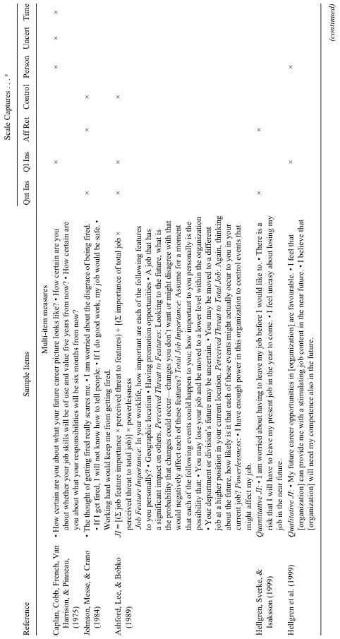

NOTE: complex table shown as an image of the PDF; the text below is a rough machine extraction and may be mis-aligned.

**extracted text (unreliable layout)**

Page 9

1919

Scale Captures . . . a

Reference Sample Items Qnt Ins Ql Ins Aff Rct Control Person Uncert Time

De Witte (2000; see Vander

Elst, De Witte, & De

Cuyper, 2014)

*JI Scale* • Chances are, I will soon lose my job. • I feel insecure about the future of my job. • I

think I might lose my job in the near future. • I am sure I can keep my job. ×

Probst (2003) *Job Security Index*: What is the future of your job with this organization like? • sure • uncertain •

can depend on being here • up in the air • stable • questionable × ×

Probst (2003) *Job Security Satisfaction Scale*: What is your job security like? • satisfactory • looks optimistic •

more secure than most in my job or profession • acceptable × ×

Huang, Niu, Lee, &

Ashford (2012) *Affective JI Scale*: • I lose sleep worrying about my future with this company. • I am tense about

maintaining my current job employment status. • I am scared by the thought of losing my job. • I

am troubled by the thought of losing my job.

× ×

O’Neill & Sevastos (2013) *Job Loss Insecurity*: • I am certain of losing my job. • I am uncertain about my future with this

organization. • No matter how hard I work there is no guarantee that I am going to keep my

job. *Job Changes Insecurity*: • I am expecting unfavorable changes to my job. • I will probably

lose many features of my job that I value the most. *Organizational Survival Insecurity*: • Senior

management is really trying to build this organization and make it successful. *Marginalization*

*Insecurity*: • I feel as though management is avoiding me.

× × ×

Van den Broeck et al.

(2014) *Qualitative JI*: • I feel insecure about the characteristics and conditions of my job in the future. •

Chances are, my job will change in a negative way. ×

Single-item measures

De Witte (1999) How large, in your opinion, is the probability that you will become unemployed in the near future? ×

Roskies, Louis-Guerin, &

Fournier (1993) What is the probability (0-100) of losing your job within the next year? × ×

*Note:* Scale and subscale titles are noted in italics. JI = job insecurity.

aQnt Ins = quantitative insecurity; Ql Ins = qualitative insecurity; Aff Rct = affective reactions; Person = person (vs. job) referent; Uncert = uncertainty (vs. likelihood); Time = time frame.

**Table 2 (continued)**

Page 10

1920 Journal of Management / July 2017

Multiplicative scales have been highly criticized on conceptual and statistical grounds (Evans, 1991). Specifically, (a) only the highest and lowest possible scores yield unique solutions, making other scores impossible to interpret; (b) not every total score is possible, making the measure ordinal, not interval; and (c) analyses with a multiplicative measure amount to including a cross-product in a regression model without including its constituent components.

*A Measurement Agenda*

Moving forward, researchers should use scales and items that more precisely assess JI, and they should abandon multiplicative scoring. With this regard, the Probst (2003) and De Witte (2000; see Vander Elst, De Witte, & De Cuyper, 2014) measures focus on overall perceptions of threat of job loss. The latter has been validated in several languages. Research has found measures of overall perceptions to be preferable to composite scales (e.g., Crossley, Bennett, Jex, & Burnfield, 2007), and these measures might outperform measures that ask about specific threats (e.g., total job scale of Ashford et al., 1989), although this remains an empirical question.

Several other measurement issues are important for future research to address, as illustrated in the right three columns of Table 2. First, scrutiny of the items in qualitative JI measures raises questions about the *referents* of some of the scales. The Van den Broeck et al. (2014) and O’Neill and Sevastos (2013) job changes insecurity scales focus on changes to the job and more explicitly capture the notion of potential loss that underlies JI. In contrast, the Caplan, Cobb, French, Van Harrison, and Pinneau (1975) and, perhaps to a lesser extent, the Hellgren et al. (1999) scales appear more oriented to future career prospects and occupational insecurity. Research is needed to examine the extent to which these scales overlap. Research should also investigate whether a person concerned about the need for his or her skills might anticipate job loss; thus, these scales blur quantitative and qualitative JI.

The second issue concerns *uncertainty versus likelihood phrasing* of items. Conceptually, uncertainty is maximized at the midpoint in likelihood scales, where higher scores reflect relatively greater, albeit still imperfect, certainty of loss (i.e., “I am likely to lose my job”). Research is needed to understand how participants respond to these different phrasings and the implications for interpreting results. A third issue concerns the *time frame* of scaling. Roskies and Louis-Guerin (1990) suggest that bounding JI within a particular time frame (e.g., probability of losing one’s job in the next year) might help distinguish acute and chronic JI, although it is important to note that this cannot capture variability in JI over time. However, Manski and Straub (2000) cautioned that because people might quit to preempt job loss, intentions to quit might confound items inquiring about likelihood of loss in a particular time frame. Future research should explore this potential confound and whether it is helpful to instruct participants to answer items independently of intentions to quit.

In summary, JI research needs to use uncontaminated measures that facilitate clear interpretations of results. Several existing measures appear to meet these criteria. Yet, research is needed to examine questions related to (a) global versus facet measures, (b) person versus job referents in qualitative JI scales, (c) uncertainty versus likelihood phrasing, and (d) whether intentions to quit serve as a confound for measures of JI.

Page 11

1921

**Table 3**

#### **Summary of Research on Antecedents of Job Insecurity**

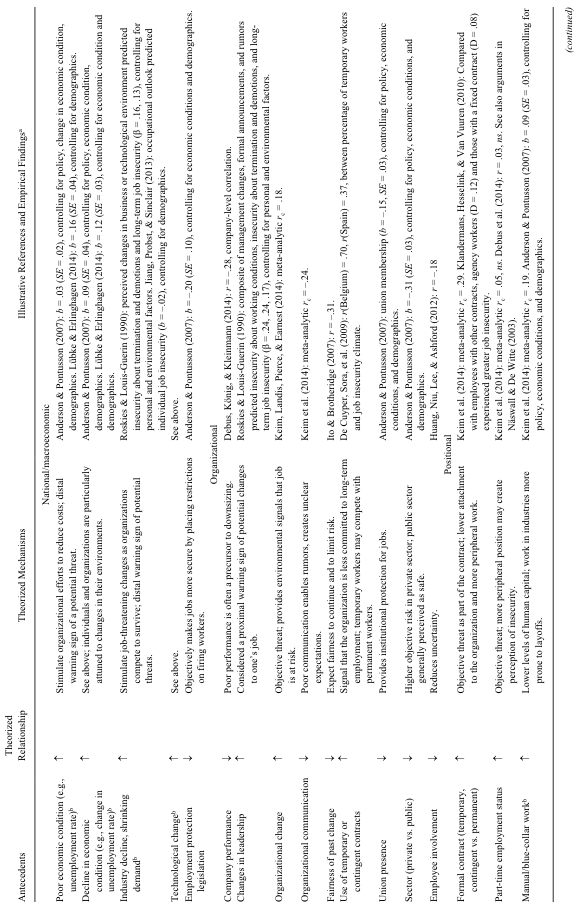

NOTE: complex table shown as an image of the PDF; the text below is a rough machine extraction and may be mis-aligned.

**extracted text (unreliable layout)**

Page 12

1922

Antecedents Theorized

Relationship Theorized Mechanisms Illustrative References and Empirical Findingsa

Individual: Demographic

Organizational tenure ↓ Higher tenure is associated with more firm-specific skills. Lübke & Erlinghagen (2014): *b* = –.04 (*SE* = .01), controlling for demographics.

Age ↑/↓ Older workers could have a perceptual sensitivity to

threats; in contrast, employers take seniority into

account in reductions.

Keim et al. (2014): meta-analytic *r*c = –.07. Anderson & Pontusson (2007): *b* = –.01 (*SE* = .00),

controlling for policy, economic conditions, and demographics. Dekker (2010): β = –.08, controlling for

demographics.

Womenb ↑/? Lower power in labor market creates sensitivity to threats;

employment in more precarious jobs, but demand and

discrimination protection might reduce threats.

Keim et al. (2014): meta-analytic *r*c = –.03, *ns*. Anderson & Pontusson (2007): *b* = –.04 (*SE* = .02), *ns*,

controlling for policy, economic conditions, and demographics. Dekker (2010): β = –.07, controlling for

demographics. Lübke & Erlinghagen (2014): *b* = .15 (*SE* = .04), controlling for demographics.

Minority statusb ↑ Discrimination; disparities in occupational characteristics

and opportunities for human capital development;

perceptual bias based on negative workplace

experiences.

Yang & Zheng (2015): odds for black workers experiencing job insecurity as compared with white workers

= 2.47, controlling for human capital and organizational factors.

Education levelb ↓ Education is a key component of human capital and

therefore promotes job security. Keim et al. (2014): meta-analytic *r*c = –.04, *ns*. Anderson & Pontusson (2007): *b* = –.02 (*SE* = .00),

controlling for policy, economic conditions, and demographics.

Individual: Experiential

Perceived employabilityb ↓ Employers use job security to attract and retain

employable workers; employable less likely to appraise

events as job threatening.

De Cuyper, Bernhard-Oettel, Berntson, De Witte, & Alarco (2008): *r* = –.14. De Cuyper, Mäkikangas,

Kinnunen, Mauno, & De Witte (2012): *r* = –.18 with job insecurity assessed 1 year later, cross-lagged

panel coefficient over 1 year = –.08.

Training experiences ↓ Investment in human capital. Kohlrausch & Rasner (2014): *b* = –.20 (*SE* = .09), relationship strengthens for those with lower levels of

education.

Role ambiguity, role conflict ↑ Uncertainty about role and performance leads to

perception of job at risk. Keim et al. (2014): meta-analytic *r*c ambiguity = .28, conflict = .20.

Emotional exhaustion ↑ Exhausted employees might be vulnerable to job loss due

to poorer performance. De Cuyper, Mäkikangas, Kinnunen, Mauno, & De Witte (2012): *r* = .16, with job insecurity assessed 1 year

later, cross-lagged panel coefficient = .05.

Prior unemployment ↑ Creates predisposition to perceive threats; psychological

spillover. Ellonen & Nätti (2015; 2008 model): logistic coefficient = 1.2 predicting dichotomized job insecurity.

Roskies & Louis-Guerin (1990): predicted working condition insecurity, insecurity about termination and

demotion, and long-term insecurity (β = .15, .18, .09), controlling for personal and environmental factors.

Individual: Personality

External locus of controlb ↑ Predisposition to view one’s future as controlled by

environmental events. Keim et al. (2014): meta-analytic *rc =* .25. Debus et al. (2014): *r* = .38.

Negative affectivityb ↑ Tendency to appraise events negatively. Debus et al. (2014): *r* = .19.

Low self-esteemb ↑ Tendency to perceive self as unworthy and incapable. Kinnunen, Feldt, & Mauno (2003): self-esteem cross-lagged panel coefficient over 1 year, β = –.08.

Low core self-evaluationsb ↑ Tendency to perceive threats in one’s environment. Låstad, Berntson, Näswall, & Sverke (2014): core self-evaluations associated with quantitative and

qualitative job insecurity (*r* = –.27, –.29) assessed 1 year later.

Interpersonal

Workplace bullying ↑ Bullying can involve threatening jobs and creating

undesirable job conditions. Glambek, Matthiesen, Hetland, & Einarsen (2014): *r* = .24 with job insecurity assessed 6 months later.

aCorrected meta-analytic correlations (*r*c) are provided for those predictors included in the Keim et al. (2014) meta-analysis. Additional illustrative references are not included in the meta-

analysis. Preference is given to large-scale studies (e.g., Anderson & Pontusson, 2007) in listing illustrative references. All findings are statistically significant unless followed by *ns*. Bivariate

correlations are presented if provided in the original paper.

bAntecedent conditions that enhance both job insecurity and vulnerabilities, thus creating particularly perilous conditions.

**Table 3 (continued)**

Page 13

Shoss / Job Insecurity 1923

#### **Sources of JI**

The majority of research has focused on JI’s consequences, with relatively less research devoted to antecedents. To guide future work, this section reviews past research on antecedents, suggests potential mechanisms linking antecedents to JI, and proposes several new categories of predictors. To lay the groundwork for this discussion, Table 3 summarizes the current state of research regarding antecedents theorized to affect JI.

*Antecedents*

Although JI is a perceptual phenomenon, these perceptions generally have their basis in environmental threats (Klandermans, Hesselink, & Van Vuuren, 2010). For instance, JI tends to rise with a rising national unemployment rate (Anderson & Pontusson, 2007) and in response to technological and other changes in the business environment (e.g., globalization) that contribute to industry and occupational decline, shrinking demand, and the outsourcing of labor (Jiang, Probst, & Sinclair, 2013; Lübke & Erlinghagen, 2014; Roskies & Louis- Guerin, 1990). From a policy perspective, employment protection legislation (e.g., notice periods, severance pay) enhances the difficulty of firing workers and reduces JI (Anderson & Pontusson, 2007).

At the company level, company performance, management changes, as well as formal and informal announcements of impending changes serve as more proximal warning signs that one’s job might be at risk and are accordingly associated with increased JI (Debus, König, & Kleinmann, 2014; Ellonen & Nätti 2015; Keim, Landis, Pierce, & Earnest, 2014; Roskies & Louis-Guerrin, 1990). Union membership reduces JI, while private sector employment increases it (Anderson & Pontusson, 2007). Consistent with the notion that temporary positions are inherently insecure, temporary employees report greater JI (Keim et al., 2014). Interestingly, permanent workers in organizations that employ greater proportions of temporary workers report greater JI (De Cuyper, Sora, De Witte, Caballer, & Peiró, 2009). Finally, consistent with economic and technological trends that threaten blue-collar work, blue-collar workers report higher levels of JI (Kalleberg, 2011; Keim et al., 2014).

Individual variables are also relevant. Debus et al. (2014) found that the personality traits of negative affectivity and locus of control explained nearly double the amount of variance in JI perceptions as did company performance and contract type. Other traits, such as low core self-evaluations and low self-esteem, as well as several experiential (e.g., emotional

**Table 4 Typology of Mechanisms and Foci Linking Antecedents to Job Insecurity**

[output not shown]

NOTE: table converted from PDF layout to HTML text; cell boundaries are reconstructed. See PDF if exact alignment matters.

Page 14

1924 Journal of Management / July 2017

exhaustion) and demographic factors (e.g., minority status, tenure), have been linked to JI (De Cuyper, Mäkikangas, Kinnunen, Mauno, & De Witte, 2012; Låstad, Berntson, Näswall, & Sverke, 2014; Yang & Zheng, 2015). Although one might expect to find person-environment interactions, the existing evidence is somewhat weak (Debus et al., 2014). The general logic is that environmental conditions create threats, while individual characteristics create heightened vigilance to these threats. However, research is needed to examine the extent to which various antecedent conditions indeed operate in such a manner.

*Mechanisms and Threat Foci*

It remains unclear if various antecedents, especially those at the individual level, engender JI because they are objectively associated with increased risk and/or because they create a perceptual bias leading to greater risk perception. For example, is prior unemployment associated with JI (Ellonen & Nätti, 2015) because it leads one to accept more objectively insecure work (e.g., temporary or contingent work) or because it creates a “psychological spillover” (P. R. Davis, Trevor, & Feng, 2015) that predisposes a person to perceive greater threats? The former is indicative of a selection mechanism, whereby antecedents lead to JI by virtue of creating more objective threats—for example, by stimulating employment in at-risk jobs or behavior that puts one’s job at risk. In contrast, perception mechanisms capture that antecedents can influence how individuals subjectively perceive their environment by (a) stimulating higher baseline perceptions of threats and/or (b) amplifying or lessening JI in response to more objective threats. Empirically, selection mechanisms raise the possibility that some antecedents affect JI indirectly. For example, if prior unemployment predicts JI because it leads people to be disproportionately employed in more insecure jobs (e.g., temporary positions), one would expect to find that contract type mediates the prior unemployment-JI relationship. However, one would expect (a) direct effects if prior unemployment creates higher overall levels of threat perception and (b) moderated effects if prior unemployment serves to amplify JI in response to temporary contracts or other threats.

To provide greater insight into these mechanisms, Table 4 introduces a 2 × 2 typology that crosses the selection/perception mechanisms with the specific foci of threats. Although surprisingly ignored in the literature, Jacobson and Hartley (1991) noted that threats to job security can be person independent, meaning that the job is at risk regardless of the holder (labeled here *job-at-risk threats*), or person dependent, meaning that one’s continued employment in a given job is at risk (*person-at-risk threats*) although the position itself may continue. This typology suggests that antecedents give rise to JI by virtue of selection and/or perception mechanisms related to job-at-risk or person-at-risk threats.

*Uncovering New Predictors*

The typology is valuable not only for understanding how and why antecedents relate to JI but also for expanding research on antecedents of JI. This is especially the case for personat-risk predictors, which have been largely neglected in the JI literature. To this aim, five new sets of antecedents are ripe for empirical investigation: individual performance, organizational performance management systems, organizational culture, supervisor-subordinate relationships, and self-employment. For example, poor task performance, high absenteeism,

Page 15

Shoss / Job Insecurity 1925

and counterproductive work behaviors, although typically viewed as outcomes of JI, should predict JI by virtue of placing individual jobholders at risk. People working in organizations using forced ranking systems (especially if rankings are tied to reductions in force), in organizations with competitive cultures, and in highly political environments likely experience greater JI. These environments might not only create threats for particular jobholders but also enhance vigilance to potential threats. Poor relationships with supervisors might induce threats via selection and/or perceptual mechanisms (Hershcovis & Barling, 2010). Indeed, participants in O’Neill and Sevastos’s (2013) qualitative study reported that that they felt insecure about the future of their jobs when they perceived that superiors were avoiding them and when they felt excluded from relevant workplace conversations. In contrast, high-quality relationships with a supervisor might shield employees from risk (Lawrence, Halbesleben, & Paustian-Underdahl, 2013). Finally, JI research has largely ignored the self-employed, although Schonfeld and Mazzola’s (2015) qualitative study revealed several sources of JI among self-employed workers. Importantly, for self-employed workers, the line between job-at-risk threats and person-at-risk threats may be blurred. Clearly, much more research is needed to fully map the antecedent space.

*Summary*

Environmental conditions as well as individual factors predict JI. They do so by creating threats and/or stimulating enhanced perception of threats. The position itself (regardless of holder) might be threatened, or threats might be localized to specific individuals. The proposed 2 × 2 typology of mechanisms and threat foci aims to stimulate (a) greater insight into why and how antecedent conditions predict JI and (b) the identification of additional antecedents, including personal performance, management strategies, and supervisor relationship quality.

#### **Reactions to JI: Mechanisms and Outcomes**

As depicted in Figure 1, JI relates to outcomes via four overarching mediating mechanisms: stress-related mechanisms, social exchange–related mechanisms, job preservation motivation, and proactive coping. The following sections describe the mechanisms and consider corresponding and competing predictions made among them.

*Stress-Related Mechanisms*

Several rationales position JI as a stressor (De Witte et al., 2016). First, JI threatens “vitamins” (Warr, 1987) and resources that are key to well-being and acquired through work, including identity, income, social connection, and social status (Jiang & Probst, 2014; Schreurs, Van Emmerik, Notelaers, & De Witte, 2010). In this vein, characterizations of JI as being stressful have drawn from work on unemployment (e.g., Jahoda, 1982) to illustrate latent (e.g., social value) and manifest (e.g., income) benefits of work threatened by JI (De Witte, 1999; Sverke et al., 2002; Vander Elst, Näswall, Bernhard-Oettel, De Witte, & Sverke, 2016). Second, researchers point out that uncertainty itself is stressful (De Witte, 1999). Third, JI violates basic psychological needs for autonomy, competence, and relatedness (Deci & Ryan, 2000; Vander Elst, Van den Broeck, De Witte, & De Cuyper, 2012; Van den

Page 16

1926 Journal of Management / July 2017

Broeck et al., 2014). These rationales align well with broader appraisal and resource-based models of stress (e.g., Folkman & Lazarus, 1985; Hobfoll, 1989). Consistent with the notion that anxiety and worry would be expected to result from the appraisal of valued resources as being threatened, the measures of affective responses to JI in Table 2 could be used as indicators of stress-related responses. While some view a lack of situational control as a mediator of JI effects (e.g., Vander Elst, De Cuyper, Baillien, Niesen, & De Witte, 2016), control over threats (i.e., situational control) is treated as a moderator here given that not all threats might be viewed as uncontrollable.

These explanations point to JI as a formidable stressor that results in a variety of strain outcomes, including poor well-being, diminished job attitudes, and poor performance, which the evidence largely supports (Cheng & Chan, 2008). This is especially the case with well-being, where the effects of JI mirror the effects of actual loss (De Witte, 1999). Moreover, given that stress narrows attention and diminishes self-regulation, stress mechanisms predict that JI results in increased workplace injuries and accidents, along with diminished creativity and increased instances of interpersonal mistreatment and organizational counterproductive work behavior (De Cuyper, Baillien, & De Witte, 2009; Niesen, De Witte, & Battistelli, 2014; Probst, 2004; Van den Broeck et al., 2014). These outcomes are discussed later, as they are the subject of corresponding and competing predictions made by several perspectives. That JI threatens key purposes and benefits of working and frustrates basic psychological needs predicts outcomes beyond the workplace. For example, several studies find that parents’ JI is negatively associated with children’s academic performance, career self-efficacy, work beliefs, and work attitudes (e.g., Barling, Dupré, & Hepburn, 1998; Lim & Sng, 2006; Zhao, Lim, & Teo, 2012). Arguments in the group conflict literature suggest that JI might worsen attitudes toward groups seen as competing for jobs. Indeed, JI is weakly associated with negative attitudes toward immigration (Billiet, Meuleman, & De Witte, 2014). Research is needed to investigate potential consequences for the workplace, such as discrimination.

*Social Exchange–Related Mechanisms*

Social exchange theories offer another lens through which to view JI—namely, as an imbalance in the exchange relationship between employee and employer. From the perspective of psychological contract theory, JI reflects a breach of the relational psychological contract, wherein employees exchange loyalty and commitment for security and other socioemotional benefits (De Cuyper & De Witte, 2006, 2007). Viewed through the lens of justice theory, JI lessens the rewards that employees receive for their efforts and is therefore likely to be perceived as unjust (Piccoli & De Witte, 2015). Thus, the former suggests that employees view JI as an imbalance between obligations and inducements; the latter, between inputs and outcomes.

Like the stress perspective, social exchange mechanisms (e.g., Gakovic & Tetrick, 2003; Siegrist, 1996) predict that employees will respond to JI with ill-being, lessened job attitudes, and lessened contributions to the organization (De Cuyper & De Witte, 2006; Piccoli & De Witte, 2015; Reisel, Probst, Chia, Maloles, & König, 2010). JI can also violate exchanges beyond the employee-organization relationship. Employees view JI as a breach of the psychological contract between union members and unions, leading to intentions to resign

Page 17

Shoss / Job Insecurity 1927

membership (De Witte et al., 2008), as well as between individuals and their elected political officials, leading to diminished trust in politicians and political institutions (Wroe, 2014).

*Job Preservation Motivation*

Because threats have not yet manifested, JI might motivate employees to act in ways that they believe might keep job or job feature loss from occurring (i.e., job preservation motivation). Job preservation strategies can take several forms. For example, employees might endeavor to demonstrate their worth to the employer by devoting extra effort toward behaviors that will be noticed and valued. For example, research finds that job-insecure employees enact more safety behaviors when the organization values safety (Probst, 2004). This line of reasoning predicts that JI results in enhanced task performance and organizational citizenship behavior, as these behaviors are likely to be noticed and valued by higher-ups (Shoss & Probst, 2012). Other active job preservation efforts include attempting to portray oneself as an ideal employee, for example by “suppressing personal values and pretending to embrace organizational values” (i.e., facades of conformity; Hewlin, Kim, & Song, 2016: 539) and being willing to make concessions (e.g., lower pay, longer hours; Otto, Hoffman-Biencourt, & Mohr, 2010). Thus, JI might result in work intensification as a job preservation strategy on the part of employees.

Employees might also pursue more passive strategies in an attempt to “fly under the radar” and refrain from behavior that would draw attention to them and put their jobs at greater risk. Evidence suggests that job-insecure employees avoid alerting the organization to potential problems (Schreurs, Guenter, Jawahar, & De Cuyper, 2015), engage in presenteeism (Miraglia & Johns, 2016), and are less likely to take advantage of work-nonwork support programs (Boswell et al., 2014). This logic predicts that job-insecure employees enact fewer organizationally directed counterproductive behaviors (Probst et al., 2007). However, given that managers are often inattentive to interpersonal behaviors during times of uncertainty, job preservation motivation predicts that employees might mistreat coworkers as a means to compete with potential rivals (Shoss & Probst, 2012). Research is needed to identify strategies that people might use to compete with others, such as hoarding knowledge (S. Wang & Noe, 2005).

Future work should consider that job preservation motivation might not only translate into efforts to demonstrate one’s own worth as an employee, but also translate into efforts to demonstrate the value of the particular position. For example, job-insecure employees might try to convince higher-ups of the importance of the job or take steps to increase the job’s importance (i.e., job aggrandizement). They might also pursue collective strategies—for example, by joining unions (Bender & Sloane, 1999) or engaging in protests (Klandermans, Van Vuuren, & Jacobson, 1991). That said, this is a complex issue (see Sverke et al., 2004), and some argue that individuals might avoid collective action for fear that doing so will threaten their jobs (Kalleberg, 2011).

*Proactive Coping*

Job preservation motivation captures individuals’ attempts to avoid loss. In contrast, proactive coping captures people’s attempts to cope ahead of time with job or job feature loss, although loss is uncertain (see Aspinwall & Taylor, 1997). For instance, some might network or proactively seek out other jobs to preempt job loss or gauge the market (Klehe, Zikic, Van

Vianen, Koen, & Buyken, 2012). Job-insecure persons might also pursue educational opportunities to enhance potential job opportunities, which future research should investigate. They might increase savings to buffer against potential income loss. Although relatively unexplored, research does find that job-insecure employees report withholding purchases of consumption goods (Lozza, Libreri, & Bosio, 2012). JI also features prominently in demanddriven explanations for social insurance, as those who perceive themselves to be at risk seek greater protection in case of loss (Dekker, 2010).

*Corresponding and Competing Predictions*

As illustrated in a general manner in Figure 1, the four mechanisms make several corresponding as well as competing predictions regarding outcomes. The paragraphs that follow describe corresponding and conflicting predictions and associated empirical evidence.

*Corresponding predictions*. *Stress-* and *social exchange*–related mechanisms predict that JI undermines personal and work-related well-being as well as job attitudes and performance, albeit for different reasons (i.e., strain and diminished self-regulation and attention effects vs. an imbalance in the social exchange relationship; Niessen & Jimmieson, 2016; Reisel et al., 2010; Sverke & Hellgren, 2002). In accordance with these arguments, longitudinal work links JI to poor mental and physical health (De Witte et al., 2016), burnout (De Cuyper et al., 2012), and diminished self-esteem (Kinnunen, Feldt, & Mauno, 2003). Jobinsecure employees also report lower levels of job satisfaction, organizational commitment, and trust (Cheng & Chan, 2008). Cross-sectional evidence suggests that social exchange– related mechanisms, especially injustice, might be a stronger mediator of well-being and job attitudinal effects (Piccoli & De Witte, 2015; Vander Elst, De Cuyper, et al., 2016). However, longitudinal research is needed to truly assess mediation and to compare the relative strength of these mechanisms across time. Performance is a subject of competing predictions and is therefore discussed below.

While the stress and social exchange perspectives are most closely aligned, other perspectives do make similar predictions regarding specific outcomes. *Stress* and *job preservation motivation* both predict poor interpersonal outcomes, and indeed JI has been linked to bullying, diminished coworker support, and diminished coworker satisfaction (De Cuyper et al., 2009; Ferrie et al., 2001; Probst, 2005). From the stress perspective, this occurs as a result of displaced aggression and diminished self-regulation. From the perspective of job preservation motivation, these are instrumental behaviors designed to compete with potential rivals (Shoss & Probst, 2012). *Stress, social exchange*, and *proactive coping* all predict that JI reduces intentions to remain, either as a response to a stressful environment, a response to a damaged social exchange relationship, or to preempt loss. The empirical evidence supports this prediction (Cheng & Chan, 2008). Finally, it is worth noting that some *job preservation* strategies might reflect *proactive coping* to the extent that they are done to facilitate coping with potential loss. For instance, employees might try to curry favor with supervisors to receive a positive recommendation or to position for a more secure job within the same organization.

*Competing predictions*. The *stress* and *social exchange* mechanisms suggest that JI creates stress and damages social exchange relationships, with the consequence of lessening employees’ willingness to put forth effort to help the organization and making it difficult

for employees to perform. Yet, *job preservation motivation* suggests that JI might motivate employees to work harder for the instrumental purpose of trying to secure their jobs. Staufenbiel and König (2010) found evidence of these competing tensions in a cross-sectional study. Specifically, they found (a) a weak positive direct effect of JI on supervisor-rated performance and (b) a stronger negative indirect effect through weakened job attitudes, leading to an overall negative effect of JI on performance (see Stynen, Forrier, Sels, & De Witte, 2015). Consistent with this finding, meta-analysis reveals an overall negative relationship between JI and performance (Cheng & Chan, 2008). Stress effects appear to be particularly detrimental to the extent that performance requires creativity and adaptability (Niessen & Jimmieson, 2016; Niesen et al., 2014). However, studies have found moderated and/or curvilinear effects of JI on performance (Brockner et al., 1992; Selenko, Mäkikangas, Mauno, & Kinnunen, 2013) and citizenship behaviors (C. F. Lam, Liang, Ashford, & Lee, 2015), suggesting that job preservation motivation might outweigh stress/social exchange effects at certain levels of JI and depending on the circumstances. Studies finding positive and negative relationships between JI and organization-focused counterproductive work behavior (Probst et al., 2007; Reisel et al., 2010) likewise suggest the existence of moderators.

Another competing prediction comes from the fact that *job preservation* and *proactive coping* both require attention and effort. In many cases, effort devoted to one is unlikely to be available to be devoted to the other. For this reason, job preservation motivation and proactive coping could be viewed as competing responses to JI, where those focused on trying to preserve their jobs are unlikely to devote energy toward proactive coping. In this sense, one might expect *stress* mechanisms to conflict with *proactive coping*, as the negative emotional arousal associated with greater stress-related reactions to JI might make it difficult for employees to devote the energy and attention required to proactively cope (Aspinwall & Taylor, 1997). Finally, while the *social exchange* perspective predicts that employees will see JI as a failure on the part of the union to protect them, the *job preservation* perspective suggests that job-insecure employees might turn to the union for support (Sverke et al., 2004). Future research is needed to examine the nature and timing of these effects.

*Summary*

The previous sections described four main mechanisms through which JI operates to effect outcomes. These reflect stress- and social exchange–related consequences, as well as strategies that employees pursue to avoid loss and to proactively cope with loss should it occur. They yield important questions for future research: What are the strategies that individuals use to try to preserve their job or job features? What are the ways by which people proactively cope with potential job or job feature loss? How do competing tensions among the mechanisms play out over time? Although a full discussion is omitted for space, research is also needed to explore potential feedback mechanisms. For example, there is some evidence that job preservation strategies can ultimately harm well-being and job attitudes (Boswell et al., 2014; De Cuyper, Schreurs, Vander Elst, Baillien, & De Witte, 2014; Hewlin et al., 2016). However, these strategies could, as intended, reduce JI (De Cuyper et al., 2014). Proactive coping might lessen concerns about being able to find an equal or better job should loss occur (affecting economic vulnerabilities, as detailed next). These questions echo the importance of longitudinal research on JI.

#### **Moderators: Impact and Key Drivers**

The previous sections reviewed general patterns of reactions to JI. The following sections describe three sets of moderating factors—threat features, economic vulnerabilities, psychological vulnerabilities—expected to shape reactions to JI and identify potential key drivers of each.

*Threat Features*

As noted in the construct clarification section, not all experiences of JI are the same, especially in terms of perceived situational control, duration, and volition. While situational control has received some attention, particularly as a conceptual explanation for the effects of variables identified here as key drivers of situational control, the other features have received less research attention and are presented largely as directions for future research.

*Perceived situational control*. Perceived situational control concerns individuals’ appraisals regarding the degree to which a given threat can be counteracted—in other words, whether there are ways to keep the threat of loss from translating into actual loss. In that sense, it can be differentiated from job control, dispositional control, and other conceptualizations (Vander Elst, De Cuyper, et al., 2016). To the extent to which people view threats as controllable, they are more likely to be motivated to take action to try to avert threats. Thus, perceived situational control should enhance job preservation motivation in light of JI (Klandermans et al., 1991). Indeed, employees appear to respond to JI with greater citizenship behaviors when threats are tied to performance (Wong, Wong, Ngo, & Liu, 2005). Stress theory also posits that situational control will reduce stress-related effects (Folkman & Lazarus, 1985).

*Threat duration*. From a temporal perspective, threats may vary from *acute* to those that are more *chronic* in nature (Roskies, Louis-Guerin, & Fournier, 1993). Prolonged uncertainty and vigilance associated with more chronic threats would be expected to enhance stress-related mechanisms, resulting in a stronger relationship between JI and stress-related outcomes (Burchell, 2011; Ferrie et al., 2001). Indeed, in one of the few studies to address duration, Burgard et al. (2009) found that the detrimental well-being impact of JI compounds over time. As a related consequence, prolonged uncertainty should make it difficult for individuals to sustain effort toward job preservation strategies and proactively cope.

*Volition*. As previously noted, some might enter insecure job situations voluntarily—for example, because these situations offer flexibility, opportunities for training, or some other benefits (e.g., for a discussion of voluntary temporary workers, see De Cuyper, De Jong, et al., 2008; for a discussion of voluntary self-employed, see Schonfeld & Mazzola, 2015). People might also support decisions in their organizations that enhance JI (e.g., about introducing new technologies). Much remains unknown about how volition shapes reactions to JI. From a theoretical standpoint, personal choice would be expected to assuage the extent to which JI frustrates autonomy needs, thus buffering stress-related effects (De Cuyper, De Jong, et al., 2008; Deci & Ryan, 2000). Moreover, those entering job-insecure situations voluntarily might be more attuned to positive aspects of these situations, with the consequence of reducing negative stress and social exchange consequences of JI (De Cuyper, De Jong,

et al., 2008; De Cuyper & De Witte, 2007). That said, De Cuyper and De Witte (2007) found that JI affects commitment more for voluntary than involuntary temporary workers, but this unexpected finding might be due to the operationalization of volition. Those who are involuntarily in a job-insecure situation would be expected to put forth greater effort in an attempt to make their jobs more secure. However, those who enter these situations voluntarily might view them more positively and respond with greater effort in order to remain. For an excellent discussion of these issues with reference to temporary workers, see De Cuyper, De Jong, et al. (2008).

*Key drivers of threat features*. Threat features provide levers through which various factors shape reactions to JI. For instance, job control or participative decision making could afford individuals opportunities for situational control (Probst, 2003). Studies have revealed that these variables buffer the negative impact of JI on several outcomes, including satisfaction, withdrawal, engagement, and health complaints (Barling & Kelloway, 1996; Probst, 2005; Schreurs et al., 2010; but see Vander Elst et al., 2011). Organizational communication, organizational justice, and a high-quality relationship with one’s supervisor might promote perceptions of situational control by clarifying expectations and signaling that effort will be rewarded. Accordingly, research finds buffering effects of these variables on several negative effects of JI (Jiang & Probst, 2014; Loi, Ngo, Zhang, & Lau, 2011; Schreurs, Van Emmerik, Günter, & Germeys, 2012; Sora, Caballer, Peiró, Silla, & Gracia, 2010; H. Wang, Lu, & Siu, 2015). Although unions have been theorized to enhance the perceived controllability of threats, research is unclear with this regard (Hellgren & Chirumbolo, 2003). The source of JI is also relevant. For example, announcements of impending layoffs would spur a relatively acute experience of JI. Finally, personality- and career-related factors might affect voluntary employment in more precarious jobs (De Cuyper, De Jong, et al., 2008; Schonfeld & Mazzola, 2015).

*Economic Vulnerabilities*

Economic vulnerabilities refer to concerns about job and income replacement should loss occur (Anderson & Pontusson, 2007; Berglund, Furåker, Vulkan, 2014). Specifically, *labor market insecurity* reflects insecurity about one’s prospects of finding a job of equal or better quality on the external labor market. Labor market insecurity corresponds well with the notion of perceived external employability, as articulated by Vanhercke, De Cuyper, Peeters, and De Witte (2014). *Income insecurity* reflects concerns about income replacement should loss occur. The notion of economic vulnerabilities has its roots in earlier discussions about job dependence. However, the meaning of the term *job dependence* is somewhat ambiguous, and it has been used in several ways (e.g., Cheng & Chan, 2008; Greenhalgh & Rosenblatt, 1984; Ito & Brotheridge, 2007; Richter, Näswall, Bernhard-Oettel, & Sverke, 2014). High levels of economic vulnerabilities heighten the threat posed by JI and heighten stress-related reactions. In accordance with this idea, research finds that those who are concerned about being able to find a new job and/or replace lost income have more negative affective reactions to JI (Anderson & Pontusson, 2007; Berglund et al., 2014; Ito & Brotheridge, 2007). Workers with fewer labor market prospects, such as manual and bluecollar workers, respond to JI with increased strain (Sverke et al., 2002). One might anticipate that those more economically vulnerable are more motivated to try to secure their jobs

because they anticipate greater challenges replacing the job and/or income should loss occur. However, given the heightened stress reactions, it is unclear whether such efforts are likely to succeed. Those most economically vulnerable may have challenges coping proactively because they have less initial resources on which to draw and potentially less human capital (Vanhercke et al., 2014). In support of this idea, JI is more strongly associated with turnover intentions among those who report greater perceived employability (Berntson, Näswall, & Sverke, 2010), suggesting that those who are the most employable have greater opportunities to proactively cope.

*Key drivers of economic vulnerabilities*. Economic vulnerabilities are linked to context, defined by Johns (2006) in an omnibus sense as reflecting the journalist’s heuristics of where (e.g., country, industry), when (e.g., historical time), who (e.g., occupation, demographic contexts), and why (e.g., rationale for data collection). The first three are most relevant here and together create individuals’ “situational opportunities and constraints” (Johns, 2006: 386) for replacing loss (see e.g., Vanhercke et al., 2014). For example, research across a number of Organisation for Economic Co-operation and Development countries finds that country-level unemployment benefits are negatively associated with worries over JI (Anderson & Pontusson, 2007). Moreover, country-level labor market (e.g., job search assistance, worker training) and income security (e.g., unemployment benefits) expenditures buffer the impact of JI on job attitudes (Debus, Probst, König, & Kleinmann, 2012).

Also relevant is the state of the economy, as both income and labor market insecurity increase along with a deteriorating state of the economy (Anderson & Pontusson, 2007; Lübke & Erlinghagen, 2014). Accordingly, the negative impact of JI on well-being has been found to be stronger in times of economic downturn (J. Lam, Fan, & Moen, 2014). Jobs that provide learning opportunities have been found to reduce labor market insecurity (Dekker, 2010) and thus would be expected to buffer JI effects. Likewise, competency-based employability (Berntson et al., 2010; Vanhercke et al., 2014), personal and professional networks, as well as traits (e.g., external locus of control; Dekker, 2010) and demographic factors (e.g., education, age; Anderson & Pontusson, 2007; Cheng & Chan, 2008; Manski & Straub, 2000) that affect labor market insecurity would be expected to contribute to greater worry over threats and associated detrimental consequences. Finally, household income and savings and, especially in the United States, access to alternative sources of health care coverage might reduce economic vulnerabilities (Schonfeld & Mazzola, 2015). To summarize, economic vulnerabilities—including both labor market and income insecurity—produce more detrimental reactions to JI. Key drivers include national social safety net policies, macroeconomic conditions, and demographics.

*Psychological Vulnerabilities*

Reactions to JI are not simply a function of whether individuals can replace what is lost. Rather, they are a function of the degree of potential loss from a psychological standpoint—in particular, the extent to which people have important identities, roles, and expectations tied to their job or its security. The final set of moderating conditions, *psychological vulnerabilities*, thus concerns the extent to which JI threatens important identities, roles, and expectations. Psychological vulnerabilities heighten stress associated with JI, given that JI poses an even greater threat to the self under these circumstances. Accordingly, research finds that people who

strongly identify with their jobs and who base a large part of their self-esteem on work-related achievement respond more negatively to JI (Blom, Richter, Hallsten, & Svedberg, 2015; Probst, 2000). Similar effects would be expected under conditions of high on-the-job embeddedness, which captures psychological and social investment in one’s job (Crossley et al., 2007). Psychological vulnerabilities—in particular, expectations regarding job security—can affect the degree to which JI is experienced as an imbalance in the social exchange relationship. For example, research finds that those who have greater expectations regarding security perceive JI as more unfair, are less committed, and have greater intentions to quit (Bernhard-Oettel, De Cuyper, Schreurs, & De Witte, 2011). While those who are most psychologically vulnerable might be most motivated to preserve their jobs, stress-related effects may counteract these efforts (e.g., for findings regarding job-involved employees, see Probst, 2000).

*Key drivers of psychological vulnerabilities*. Several factors shape identities, roles, and expectations and would therefore be expected to affect reactions to JI. For example, past research reveals that JI is more distressing for men given the greater threat to their identity and traditional role as the breadwinner (J. Lam et al., 2014). However, women with egalitarian, as opposed to traditional, gender values experience similar responses to JI as do men (Gaunt & Benjamin, 2007). JI has been found to be more detrimental among employees with collectivist cultural values, as it threatens culturally valued group ties and security (reflecting greater psychological vulnerability; Probst & Lawler, 2006).

Elements of the formal and psychological contract are also relevant. Temporary employees engage in less relational contracting than permanent employees and are therefore less likely to view JI as a violation of their expectations (De Cuyper & De Witte, 2006). Thus, although employees in temporary positions experience greater JI, permanent employees experience more severe consequences in terms of satisfaction, commitment, and sickness absenteeism, reflecting their greater psychological vulnerabilities (De Cuyper & De Witte, 2006; Klandermans et al., 2010). The greater their investments into their positions (e.g., in terms of tenure, sacrifices made for the job), the more security individuals might expect and the more likely it is that they will see JI as unjust or a breach of expectations. In contrast, some have argued that an expansive view of one’s career (i.e., a “boundary-less” career orientation) can enable flexibility and reduce negative reactions to JI by lowering expectations for security (Klehe et al., 2012; Otto et al., 2010). With this regard, personality is expected to be relevant, as traits shape expectations, goals, and values. In summary, to the extent that JI threatens key components of one’s identity, sources of esteem, and expectations, people are psychologically vulnerable to greater detrimental reactions to JI.

*Summary, Implications, and Further Directions*

This framework provides an accounting of key variables that would be expected to affect reactions to JI. In doing so, it provides a rich perspective on who is most adversely affected by JI and why. These moderating factors further suggest several avenues through which organizations and policy makers can intervene to affect reactions to JI, and they pave the way for future work to uncover additional moderators. They also suggest particular challenges for organizations, as those most predisposed to provide effort and loyalty (i.e., high job involvement) are at greatest risk for negative well-being and attitudinal consequences of JI. Viewed in conjunction with the previous discussion of antecedents, this framework contributes to

research and practice by providing a means to identify particularly perilous conditions: those variables (notated in Table 3) that not only enhance JI but also predict more harmful reactions by virtue of their impact on one or more moderating conditions. For instance, by virtue of experiencing both greater JI and greater economic vulnerabilities, certain groups (e.g., lower educated, blue-collar) may be particularly disadvantaged (Kalleberg, 2011).

Beyond investigating the ideas set forth here, future work might expand the framework in several directions. First, future work should examine whether effects differ according to quantitative versus qualitative JI. For example, economic vulnerabilities might play a larger role in shaping reactions to quantitative JI since they are more focused on the job as a whole. Second, future research might extend the model to examine JI as a collective construct. Emerging research suggests that JI climate (shared perceptions of JI) influences outcomes above and beyond individual JI and can exacerbate the effects of individual JI (e.g., Jiang & Probst, 2016; Sora, De Cuyper, Caballer, Peiró, & De Witte, 2013). Third, and relatedly, research might expand the framework to examine group- and organization-level outcomes (e.g., Shoss & Probst, 2012).

#### **Conclusions**

This article provides an overview of the rapidly growing JI literature aimed at identifying crucial gaps and providing a general framework through which to guide future work. To that end, it calls for greater attention to the conceptualization and measurement of JI, specifically to eliminate restrictive construct assumptions and measurement confounds. Research is additionally needed to expand knowledge of antecedents of JI, in particular by recognizing that JI occurs not only when individuals perceive that future of the job itself is threatened but also when they perceive certain risks to themselves as jobholders. The proposed framework calls for greater attention to ways that employees try to counteract threats and proactively cope with potential loss, as well as the role that moderators play in shaping these and other reactions to JI. These questions demand longitudinal work to more precisely test hypotheses (e.g., regarding increases or decreases in attitudes or behaviors) and explore feedback loops. By laying out key gaps needing research attention, the discussion provided here will ideally help stimulate research that produces greater insights into this increasingly frequent and important experience.

#### **References**

Ahearn, R. J. 2012. *Globalization, worker insecurity, and policy approaches* (Report No. RL34091). Washington,

DC: Congressional Research Service. Anderson, C. J., & Pontusson, J. 2007. Workers, worries and welfare states: Social protection and job insecurity in

15 OECD countries. *European Journal of Political Research*, 46: 211-235. Ashford, S., Lee, C., & Bobko, P. 1989. Content, causes, and consequences of job insecurity: A theory-based mea-

sure and substantive test. *Academy of Management Journal*, 32: 803-829. Aspinwall, L. G., & Taylor, S. E. 1997. A stitch in time: Self-regulation and proactive coping. *Psychological*

*Bulletin*, 12: 417-436. Barling, J., Dupré, K. E., & Hepburn, C. G. 1998. Effects of parents’ job insecurity on children’s work beliefs and

attitudes. *Journal of Applied Psychology*, 83: 112-118. Barling, J., & Kelloway, E. K. 1996. Job insecurity and health: The moderating role of workplace control. *Stress*

*Medicine*, 12: 253-259. Benach, J., Vives, A., Amable, M., Vanroelen, C., Tarafa, G., & Muntaner, C. 2014. Precarious employment:

Understanding an emerging social determinant of health. *Annual Review of Public Health*, 35: 229-253.

Bender, K. A., & Sloane, P. J. 1999. Trade union membership, tenure and the level of job insecurity. *Applied*

*Economics*, 31: 123-135. Berglund, T., Furåker, B., & Vulkan, P. 2014. Is job insecurity compensated for by employment and income secu-

rity? *Economic and Industrial Democracy*, 35: 165-184. Bernhard-Oettel, C., De Cuyper, N., Schreurs, B., & De Witte, H. 2011. Linking job insecurity to well-being and

organizational attitudes in Belgian workers: The role of security expectations and fairness. *International Journal of Human Resource Management*, 22: 1866-1886. Berntson, E., Näswall, K., & Sverke, M. 2010. The moderating role of employability in the association between job

insecurity and exit, voice, loyalty and neglect. *Economic and Industrial Democracy*, 31: 215-230. Billiet, J., Meuleman, B., & De Witte, H. 2014. The relationship between ethnic threat and economic insecurity in

times of economic crisis: Analysis of European Social Survey data. *Migration Studies*, 2: 295-299. Blom, V., Richter, A., Hallsten, L., & Svedberg, P. 2015. The associations between job insecurity, depressive symp-

toms and burnout: The role of performance-based self-esteem. *Economic and Industrial Democracy*. doi:10.1 177/0143831X15609118 Boswell, W. R., Olson-Buchanan, J. B., & Harris, T. B. 2014. I cannot afford to have a life: Employee adaptation to

feelings of job insecurity. *Personnel Psychology*, 67: 887-915. Brockner, J., Grover, S., Reed, T., & DeWitt, R. 1992. Layoffs, job insecurity, and survivors’ work effort: Evidence

of an inverted-u relationship. *Academy of Management Journal*, 2: 413-425. Burchell, B. J. 2011. A temporal comparison of the effects of unemployment and job insecurity on wellbeing.

*Sociological Research Online*, 16(1): 9. Burgard, S. A., Brand, J. E., & House, J. S. 2009. Perceived job insecurity and worker health in the United States.

*Social Science & Medicine*, 69: 777-785. Caplan, R. D., Cobb, S., French, J. R. P., Van Harrison, R., & Pinneau, S. R. 1975. *Job demands and worker health*.

Washington, DC: National Institute for Occupational Safety and Health. Cheng, G. H.-L., & Chan, D. K.-S. 2008. Who suffers more from job insecurity? A meta-analytic review. *Applied*

*Psychology: An International Review*, 57: 272-303. Crossley, C. D., Bennett, R. J., Jex, S. M., & Burnfield, J. L. 2007. Development of a global measure of job embedded-

ness and integration into a traditional model of voluntary turnover. *Journal of Applied Psychology*, 92: 1031-1042. Davis, G. F. 2009. The rise and fall of finance and the end of the society of organizations. *Academy of Management*

*Perspectives*, 23: 21-42. Davis, P. R., Trevor, C. O., & Feng, J. 2015. Creating a more quit-friendly national workforce? Individual layoff

history and voluntary turnover. *Journal of Applied Psychology*, 100: 1434-1455. De Cuyper, N., Baillien, E., & De Witte, H. 2009. Job insecurity, perceived employability and targets’ and perpetra-

tors’ experiences of workplace bullying. *Work & Stress*, 3: 206-224. De Cuyper, N., Bernhard-Oettel, C., Berntson, E., De Witte, H., & Alarco, B. 2008. Employability and employees’

well-being: Mediation by job insecurity. *Applied Psychology: An International Review*, 57: 488-509. De Cuyper, N., De Jong, J., De Witte, H., Isaksson, K., Rigotti, T., & Schalk, R. 2008. Literature review of theory and

research on the psychological impact of temporary employment: Towards a conceptual model. *International Journal of Management Reviews*, 10: 25-51. De Cuyper, N., & De Witte, H. 2006. The impact of job insecurity and contract type on attitudes, well-being

and behavioral reports: A psychological contract perspective. *Journal of Occupational and Organizational Psychology*, 79: 395-409. De Cuyper, N., & De Witte, H. 2007. Job insecurity in temporary versus permanent workers: Associations with

attitudes, well-being, and behavior. *Work & Stress*, 21: 65-84. De Cuyper, N., Mäkikangas, A., Kinnunen, U., Mauno, S., & De Witte, H. 2012. Cross-lagged associations between

perceived external employability, job insecurity, and exhaustion: Testing gain and loss spirals according to the conservation of resources theory. *Journal of Organizational Behavior*, 33: 770-788. De Cuyper, N., Schreurs, B., Vander Elst, T., Baillien, E., & De Witte, H. 2014. Exemplification and perceived

job insecurity: Associations with self-rated performance and emotional exhaustion. *Journal of Personnel Psychology*, 13: 1-10. De Cuyper, N., Sora, B., De Witte, H., Caballer, A., & Peiró, J. M. 2009. Organizations’ use of temporary employ-

ment and a climate of job insecurity among Belgian and Spanish permanent workers. *Economic and Industrial Democracy*, 30: 564-591. De Witte, H. 1999. Job insecurity and psychological well-being: Review of the literature and exploration of some

unresolved issues. *European Journal of Work and Organizational Psychology*, 8: 155-177.

De Witte, H. 2000. Arbeidsethos en jobonzekerheid: Meting en gevolgen voor welzijn, tevredenheid en inzet op het

werk [Work ethic and job insecurity: Assessment and consequences for well-being, satisfaction and performance at work]. In R. Bouwen, K. De Witte, H. De Witte, & T. Taillieu (Eds.), *Van groep naar gemeenschap* [From group to community]. Liber Amicorum Prof. Dr. Leo Lagrou (pp. 325-350). Leuven, Belgium: Garant. De Witte, H., Pienaar, J., & De Cuyper, N. 2016. Review of 30 years of longitudinal studies on the association

between job insecurity and health and well-being: Is there causal evidence? *Australian Psychologist*, 51: 18-31. De Witte, H., Sverke, M., Van Ruysseveldt, J. V., Goslinga, S., Chirumbolo, A., Hellgren, J., & Näswall, K. 2008.

Job insecurity, union support and intentions to resign membership: A psychological contract perspective. *European Journal of Industrial Relations*, 14: 85-103. Debus, M. E., König, C. J., & Kleinmann, M. 2014. The building blocks of job insecurity: The impact of environ-

mental and person-related variables on job insecurity perceptions. *Journal of Occupational and Organizational Psychology*, 87: 329-351. Debus, M. E., Probst, T. M., König, C. J., & Kleinmann, M. 2012. Catch me if I fall! Enacted uncertainty avoidance

and the social safety net as country-level moderators in the job insecurity–job attitudes link. *Journal of Applied Psychology*, 97: 690-698. Deci, E. L., & Ryan, R. M. 2000. The “what” and “why” of goal pursuits: Human needs and the self-determination

of behavior. *Psychological Inquiry*, 11: 319-338. Dekker, F. 2010. Labour flexibility, risks and the welfare state. *Economic and Industrial Democracy*, 31: 593-611. Ellonen, N., & Nätti, J. 2015. Job insecurity and the unemployment rate: Micro- and macro-level predictors of per-

ceived job insecurity among Finnish employees 1984-2008. *Economic and Industrial Democracy*, 36: 51-71. European Commission. 2007. *Towards common principles of flexicurity: More and better jobs through flexibility*

*and security*. Luxembourg: Office for Official Publications of the European Communities. Evans, M. G. 1991. The problem of analyzing multiplicative composites: Interactions revisited. *American*

*Psychologist*, 46: 6-15. Ferrie, J., Shipley, M., Marmot, M., Martikainen, P., Stansfeld, S., & Smith, G. 2001. Job insecurity in white-collar

workers: Toward an explanation of association with health. *Journal of Occupational Health Psychology*, 6: 26-42. Folkman, S., & Lazarus, R. S. 1985. If it changes it must be a process: Study of emotion and coping during three

stages of a college examination. *Journal of Personality and Social Psychology*, 48: 150-170. Gakovic, A., & Tetrick, L. E. 2003. Psychological contract breach as a source of strain for employees. *Journal of*

*Business and Psychology*, 18: 235-246. Gaunt, R., & Benjamin, O. 2007. Job insecurity, stress and gender: The moderating role of gender ideology.

*Community, Work, and Family*, 10: 341-355. Glambek, M., Matthiesen, S. B., Hetland, J., & Einarsen, S. 2014. Workplace bullying as an antecedent to job insecu-

rity and intention to leave: A 6-month prospective study. *Human Resource Management Journal*, 24: 255-268. Greenhalgh, L., & Rosenblatt, Z. 1984. Job insecurity: Toward conceptual clarity. *Academy of Management Review*,

9: 438-448. Greenhalgh, L., & Rosenblatt, Z. 2010. Evolution of research on job insecurity. *International Studies of Management*

*and Organization*, 40: 6-19. Heaney, C. A., Israel, B. A., & House, J. S. 1994. Chronic job insecurity among automobile workers: Effects on job

satisfaction and health. *Social Science and Medicine*, 38: 1431-1437. Hellgren, J., & Chirumbolo, A. 2003. Can union support reduce the negative effects of job insecurity on well-being?

*Economic and Industrial Democracy*, 24: 271-289. Hellgren, J., Sverke, M., & Isaksson, K. 1999. A two-dimensional approach to job insecurity: Consequences for

employee attitudes and well-being. *European Journal of Work and Organizational Psychology*, 8: 179-195. Hershcovis, M. S., & Barling, J. 2010. Towards a multi-foci approach to workplace aggression: A meta-analytic

review of outcomes from different perpetrators. *Journal of Organizational Behavior*, 31: 24-44. Hewlin, P. F., Kim, S. S., & Song, Y. H. 2016. Creating facades of conformity in the face of job insecurity: A study

of consequences and conditions. *Journal of Occupational and Organizational Psychology*, 89: 539-567. Hobfoll, S. E. 1989. Conservation of resources: A new attempt at conceptualizing stress. *American Psychologist*,

44: 513-524. Huang, G., Niu, X., Lee, C., & Ashford, S. J. 2012. Differentiating cognitive and affective job security: Antecedents

and outcomes. *Journal of Organizational Behavior*, 33: 752-769. Ito, J. K., & Brotheridge, C. M. 2007. Exploring the predictors and consequences of job insecurity’s components.

*Journal of Managerial Psychology*, 22: 40-64.

Jacobson, D., & Hartley, J. 1991. Mapping the context. In J. Hartley, D. Jacobson, B. Klandermans, & T. Van

Vuuren (Eds.), *Job insecurity: Coping with jobs at risk*: 1-22. London: Sage. Jahoda, M. 1982. *Employment and unemployment: A social-psychological analysis*. London: Cambridge University Press. Jiang, L., & Probst, T. M. 2014. Organizational communication: A buffer in times of job insecurity? *Economic and*

*Industrial Democracy*, 35: 557-579. Jiang, L., & Probst, T. M. 2016. A multilevel examination of affective job insecurity climate on safety outcomes.

*Journal of Occupational Health Psychology*, 21: 366-377. Jiang, L., Probst, T. M., & Sinclair, R. R. 2013. Perceiving and responding to job insecurity: The importance of

multilevel contexts. In A. Antoniou & C. Cooper (Eds.), *The psychology of the recession on the workplace*: 176-195. Cheltenham, UK: Elgar. Johns, G. 2006. The essential impact of context on organizational behavior. *Academy of Management Review*, 31:

386-408. Johnson, C. D., Messe, L. A., & Crano, W. D. 1984. Predicting job performance of low income workers: The work

opinion questionnaire. *Personnel Psychology*, 37: 291-299. Kalleberg, A. L. 2011. *Good jobs, bad jobs: The rise of polarized and precarious employment systems in the United*

*States, 1970s to 2000s*. New York: Russell Sage Foundation. Keim, A. C., Landis, R. S., Pierce, C. A., & Earnest, D. R. 2014. Why do employees worry about their jobs? A

meta-analytic review of predictors of job insecurity. *Journal of Occupational Health Psychology*, 19: 269-290. Kinnunen, U., Feldt, T., & Mauno, S. 2003. Job insecurity and self-esteem: Evidence from cross-lagged relations in

a 1-year longitudinal sample. *Personality and Individual Differences*, 35: 617-632. Klandermans, B., Hesselink, J. K., & Van Vuuren, T. 2010. Employment status and job insecurity: On the subjective

appraisal of an objective status. *Economic and Industrial Democracy*, 31: 557-577. Klandermans, B., Van Vuuren, T., & Jacobson, D. 1991. Employees and job insecurity. In J. Hartley, D. Jacobson,

B. Klandermans, & T. Van Vuuren (Eds.), *Job insecurity: Coping with jobs at risk*: 40-54. London: Sage. Klehe, U., Zikic, J., Van Vianen, A. E. M., Koen, J., & Buyken, M. 2012. Coping proactively with economic stress:

Career adaptability in the face of job insecurity, job loss, unemployment, and underemployment. In P. L. Perrewé, J. R. B. Halbesleben, & C. C. Rosen (Eds.), *The role of the economic crisis on occupational stress and well being*: 131-176. Bingley, UK: Emerald. Kohlrausch, B., & Rasner, A. 2014. Workplace training in Germany and its impact on subjective job security: Short-

or long-term returns? *Journal of European Social Policy*, 24: 337-350. Lam, C. F., Liang, J., Ashford, S., & Lee, C. 2015. Job insecurity and organizational citizenship behavior: Exploring

curvilinear and moderated relationships. *Journal of Applied Psychology*, 100: 499-510. Lam, J., Fan, W., & Moen, P. 2014. Is insecurity worse for well-being in turbulent times? Mental health in context.

*Society and Mental Health*, 4: 55-73. Låstad, L., Berntson, E., Näswall, K., & Sverke, M. 2014. Do core self-evaluations and coping style influence the

perception of job insecurity? *European Journal of Work and Organizational Psychology*, 23: 680-692. Lawrence, E. R., Halbesleben, J. R. B., & Paustian-Underdahl, S. C. 2013. The influence of workplace injuries on

work-family conflict: Job and financial insecurity as mechanisms. *Journal of Occupational Health Psychology*, 18: 371-383. Lee, C., Bobko, P., & Chen, Z. X. 2006. Investigation of the multidimensional model of job insecurity in China and

the USA. *Applied Psychology: An International Review*, 55: 512-540. Lim, V., & Sng, Q. 2006. Does parental job insecurity matter? Money anxiety, money motives and work motivation.

*Journal of Applied Psychology*, 91: 1078-1087. Loi, R., Ngo, H., Zhang, L., & Lau, V. P. 2011. The interaction between leader-member exchange and perceived job

security in predicting employee altruism and work performance. *Journal of Occupational and Organizational Psychology*, 84: 669-685. Lozza, E., Libreri, C., & Bosio, A. C. 2012. Temporary employment, job insecurity and their extraorganizational

outcomes. *Economic and Industrial Democracy*, 34: 89-105. Lübke, C., & Erlinghagen, M. 2014. Self-perceived job insecurity across Europe over time: Does changing context

matter? *Journal of European Social Policy*, 24: 319-336. Manski, C. F., & Straub, J. D. 2000. Worker perceptions of job insecurity in the mid-1990s: Evidence from the

survey of economic expectations. *The Journal of Human Resources*, 35: 447-479. Miraglia, M., & Johns, G. 2016. Going to work ill: A meta-analysis of the correlates of presenteeism and a dual-path

model. *Journal of Occupational Health Psychology*, 21: 261-283. Näswall, K. & De Witte, H. 2003. Who feels insecure in Europe? Predicting job insecurity from background vari-

ables. *Economic and Industrial Democracy*, 24: 189-215.

Niesen, W., De Witte, H., & Battistelli, A. 2014. An explanatory model of job insecurity and innovative work behav-

iour: Insights from social exchange and threat rigidity theory. In S. Leka & R. Sinclair (Eds.), *Contemporary occupational health psychology: Global perspectives on research & practice*: 18-34. Chichester, UK: Wiley Blackwell. Niessen, C., & Jimmieson, N. L. 2016. Threat of resource loss: The role of self-regulation in adaptive task perfor-

mance. *Journal of Applied Psychology*, 101: 450-462. O’Neill, P., & Sevastos, P. 2013. The development and validation of a new multidimensional Job Insecurity Measure

(JIM): An inductive methodology. *Journal of Occupational Health Psychology*, 18: 338-349. Otto, K., Hoffmann-Biencourt, A., & Mohr, G. 2010. Is there a buffering effect of flexibility for job attitudes and

work-related strain under conditions of high job insecurity and regional unemployment rate? *Economic and Industrial Democracy*, 32: 609-630. Piccoli, B., & De Witte, H. 2015. Job insecurity and emotional exhaustion: Testing psychological contract breach

versus distributive injustice as indicators of lack of reciprocity. *Work & Stress*, 29: 246-263. Probst, T. M. 2000. Wedded to the job: Moderating effects of job involvement on the consequences of job insecu-

rity. *Journal of Occupational Health Psychology*, 5: 63-73. Probst, T. M. 2003. Development and validation of the job security index and the job security satisfaction scale. A

classical test theory and IRT approach. *Journal of Occupational and Organizational Psychology*, 76: 451-467. Probst, T. M. 2004. Safety and insecurity: Exploring the moderating effect of organizational safety climate. *Journal*

*of Occupational Health Psychology*, 9: 3-10. Probst, T. M. 2005. Countering the negative effects of job insecurity through participative decision making: Lessons

from the demand-control model. *Journal of Occupational Health Psychology*, 10: 320-329. Probst, T. M., & Lawler, J. 2006. Cultural values as moderators of employee reactions to job insecurity: The role of

individualism and collectivism. *Applied Psychology: An International Review*, 55: 234-254. Probst, T. M., Stewart, S. M., Gruys, M. L., & Tierney, B. W. 2007. Productivity, counterproductivity and creativity:

The ups and downs of job insecurity. *Journal of Occupational and Organizational Psychology*, 80: 479-497. Reisel, W. D., Probst, T. M., Chia, S., Maloles, C. M., & König, C. J. 2010. The effects of job insecurity on

job satisfaction, organizational citizenship behavior, deviant behavior, and negative emotions of employees. *International Studies of Management & Organization*, 40: 74-91. Richter, A., Näswall, K., Bernhard-Oettel, C., & Sverke, M. 2014. Job insecurity and well-being: The moderating

role of job dependence. *European Journal of Work and Organizational Psychology*, 23: 816-829. Roskies, E., & Louis-Guerin, C. 1990. Job insecurity in managers: Antecedents and consequences. *Journal of*

*Organizational Behavior*, 11: 345-359. Roskies, E., Louis-Guerin, C., & Fournier, C. 1993. Coping with job insecurity: How does personality make a dif-

ference? *Journal of Organizational Behavior*, 14: 617-630. Schonfeld, I. S., & Mazzola, J. J. 2015. A qualitative study of stress in individuals self-employed in solo businesses.

*Journal of Occupational Health Psychology*, 20: 501-513. Schreurs, B., Guenter, H., Jawahar, I. M., & De Cuyper, N. 2015. Speaking up when feeling job insecure. *Journal*

*of Organizational Change Management*, 28: 1107-1128. Schreurs, B. H. J., Van Emmerik, I. H., Günter, H., & Germeys, F. 2012. A weekly diary study on the buffering

role of social support in the relationship between job insecurity and employee performance. *Human Resource Management*, 51: 259-280. Schreurs, B., Van Emmerik, H., Notelaers, G., & De Witte, H. 2010. Job insecurity and employee health: The buff-

ering potential of job control and job self-efficacy. *Work & Stress*, 24: 56-72. Selenko, E., Mäkikangas, A., Mauno, S., & Kinnunen, U. 2013. How does job insecurity relate to self-reported

job performance? Analysing curvilinear associations in a longitudinal sample. *Journal of Occupational and Organizational Psychology*, 86: 522-542. Shoss, M. K., & Probst, T. M. 2012. Multilevel outcomes of economic stress: An agenda for future research. In P.

Perrewe, C. Rosen, & J. Halbesleben (Eds.), *Research in occupational stress and well-being: The role of economic context on occupational stress and well-being*: Vol. 10, 43-86. Bingley, UK: Emerald. Siegrist, J. 1996. Adverse health effects of high-effort/low-reward conditions. *Journal of Occupational Health*

*Psychology*, 1: 27-41. Sora, B., Caballer, A., Peiró, J. M., Silla, I., & Gracia, F. J. 2010. Moderating influence of organizational justice

on the relationship between job insecurity and its outcomes: A multilevel analysis. *Economic and Industrial Democracy*, 31: 613-637.

Sora, B., De Cuyper, N., Caballer, A., Peiró, J., & De Witte, H. 2013. Outcomes of job insecurity climate: The role

of climate strength. *Applied Psychology*, 62: 382-405. Staufenbiel, T., & König, C. J. 2010. A model for the effects of job insecurity on performance, turnover intention,

and absenteeism. *Journal of Occupational and Organizational Psychology*, 83: 101-117. Staufenbiel, T., & König, C. J. 2011. An evaluation of Borg’s cognitive and affective job insecurity scales.

*International Journal of Business and Social Science*, 2(20): 1-7. Stynen, D., Forrier, A., Sels, L., & De Witte, H. 2015. The relationship between qualitative job insecurity and OCB:

Differences across age groups. *Economic and Industrial Democracy*, 36: 383-405. Sverke, M., & Hellgren, J. 2002. The nature of job insecurity: Understanding employment uncertainty on the brink

of a new millennium. *Applied Psychology: An International Review*, 51: 23-42. Sverke, M., Hellgren, J., & Näswall, K. 2002. No security: A meta-analysis and review of job insecurity and its

consequences. *Journal of Occupational Health Psychology*, 7: 242-264. Sverke, M., Hellgren, J., Näswall, K., Chirumbolo, A., De Witte, H., & Goslinga, S. 2004. *Job insecurity and union*

*membership: European unions in the wake of flexible production*. Brussels: P.I.E.-Peter Lang. Van den Broeck, A., Sulea, C., Vander Elst, T., Fischmann, G., Iliescu, D., & De Witte, H. 2014. The mediating role

of psychological needs in the relation between qualitative job insecurity and counterproductive work behavior. *Career Development International*, 19: 526-547. Van Vuuren, C. V., & Klandermans, P. G. 1990. Individual reactions to job insecurity: An integrated model. In P. J.

Drenth, J. A. Sergeant, & R. J. Takens (Eds.), *European perspectives in psychology*: Vol. 3, 133-146. Oxford: Wiley. Van Vuuren, T., Klandermans, B., Jacobson, D., & Hartley, J. 1991. Employees’ reactions to job insecurity. In J.

Hartley, D. Jacobson, B. Klandermans, & T. Van Vuuren (Eds.), *Job insecurity: Coping with jobs at risk*: 79- 103. London: Sage. Vander Elst, T., De Cuyper, N., Baillien, E., Niesen, W., & De Witte, H. 2016. Perceived control and psychologi-

cal contract breach as explanations of relationships between job insecurity, job strain and coping reactions: Towards a theoretical integration. *Stress and Health*, 32: 110-116. Vander Elst, T., De Cuyper, N., & De Witte, H. 2011. The role of perceived control in the relationship between job

insecurity and psychosocial outcomes: Moderator or mediator. *Stress and Health*, 27: 215-227. Vander Elst, T., De Witte, H., & De Cuyper, N. 2014. The Job Insecurity Scale: A psychometric evaluation across

five European countries. *European Journal of Work and Organizational Psychology*, 23: 364-380. Vander Elst, T., Näswall, K., Bernhard-Oettel, C., De Witte, H., & Sverke, M. 2016. The effect of job insecurity on

employee health complaints: A within-person analysis of the explanatory role of threats to the manifest and latent benefits of work. *Journal of Occupational Health Psychology*, 21: 65-76. Vander Elst, T., Van den Broeck, A., De Witte, H., & De Cuyper, N. 2012. The mediating role of frustration of

psychological needs in the relationship between job insecurity and work-related well-being. *Work & Stress*, 26: 252-271. Vanhercke, D., De Cuyper, N., Peeters, E., & De Witte, H. 2014. Defining perceived employability: A psychologi-

cal approach. *Personnel Review*, 43: 592-605. Wang, H., Lu, C., & Siu, O. 2015. Job insecurity and job performance: The moderating role of organizational justice

and the mediating role of work engagement. *Journal of Applied Psychology*, 100: 1249-1258. Wang, S., & Noe, R. A. 2005. Knowledge sharing: A review and directions for future research. *Human Resource*

*Management Review*, 20: 115-131. Warr, P. B. 1987. *Work, unemployment, and mental health*. Oxford: Oxford University Press. Wong, Y., Wong, C., Ngo, H., & Liu, H. 2005. Different responses to job insecurity of Chinese workers in joint

ventures and state-owned enterprises. *Human Relations*, 58: 1391-1418. Wroe, A. 2014. Political trust and job insecurity in 18 European polities. *Journal of Trust Research*, 4: 90-112. Yang, S., & Zheng, L. 2015. Perceived job insecurity of white and black workers: An expanded gap in organizations

with layoff prevention commitment. *Sociological Spectrum*, 35: 483-503. Zhao, X., Lim, V. K. G., & Teo, T. S. H. 2012. The long arm of job insecurity: Its impact on career-specific parent-

ing behaviors and youth’s career and self-efficacy. *Journal of Vocational Behavior*, 80: 619-628.